# PU learning

### Summary of training and testing process

Select final iteration data

```r
# RP_HSP - PREDICTED AS POSITIVES IN TEST THAT ARE TRUE (tp)
# RP_TOTAL - PREDICTED AS POSITIVES IN TEST TOTAL
# mean_bkpt_density - MEAN BREAKPOINTS DENSITY IN WINDOWS PREDICTED AS POSITIVES IN TEST
# mean_bkpt_density_test - MEAN BREAKPOINTS DENSITY IN WINDOWS IN TEST

pu_data <- pu_data %>%
  mutate(
    ratio_hsp = rp_hsp / test_hsp,
    rp_not_labeled = rp_total - rp_hsp,
    test_not_labeled = test_total - test_hsp,
    ratio_rest = rp_not_labeled / test_not_labeled,
    rp_hsp_ratio = rp_hsp / rp_total,
    density_ratio = mean_bkpt_density / mean_bkpt_density_test
)
pu_data$eps <- as.character(pu_data$eps)
final_iter <- pu_data %>%
  group_by(resample, eps, cancer_type, agg_level, type) %>%
  filter(iter == max(iter)) %>%
  select(iter, resample, eps, cancer_type, agg_level, type)

pu_data_final <- pu_data %>%
  inner_join(final_iter, by = c('type', 'iter', 'resample', 'eps', 'cancer_type', 'agg_level'))
```

Stats of model training process for “reliable negatives only” mode.

| cancer_type | max_iter | median_iter | median_rp_total_to_rp_hsp | median_train_unl_to_total | median_train_rn_to_total |
| --- | --- | --- | --- | --- | --- |
| blood | 5 | 3.0 | 366.10000 | 0.24813442 | 0.7509389 |
| bone | 2 | 2.0 | 38.62500 | 0.10705750 | 0.8880652 |
| brain | 5 | 2.0 | 309.00000 | 0.19641986 | 0.8028485 |
| breast | 2 | 2.0 | 36.66667 | 0.18237245 | 0.8126036 |
| liver | 2 | 1.0 | 531.25000 | 0.17659253 | 0.8224320 |
| ovary | 2 | 1.5 | 18.50000 | 0.08486977 | 0.9051800 |
| pancreatic | 5 | 2.0 | 42.88095 | 0.12006146 | 0.8789143 |
| prostate | 2 | 0.0 | 19.75000 | 0.00000000 | 0.9899527 |
| skin | 2 | 0.0 | 38.33036 | 0.00000000 | 0.9900985 |
| uterus | 2 | 2.0 | 51.25000 | 0.12662179 | 0.8685982 |

Stats of model training process for “reliable negatives and reliable positives” mode.

| cancer_type | max_iter | median_iter | n_times_train_new_pos_selected | median_rp_total_to_rp_hsp | median_train_unl_to_total | median_train_rp_to_total | median_train_rn_to_total |
| --- | --- | --- | --- | --- | --- | --- | --- |
| blood | 5 | 3 | 89 | Inf | 0.0045603082 | 0.015583085 | 0.9710530 |
| bone | 2 | 2 | 88 | 30.00000 | 0.0891089109 | 0.020460420 | 0.8900649 |
| brain | 5 | 3 | 89 | Inf | 0.0008291874 | 0.007511462 | 0.9912691 |
| breast | 5 | 2 | 89 | 62.16667 | 0.0272412448 | 0.034216174 | 0.9361282 |
| liver | 3 | 3 | 84 | 114.00000 | 0.0015608233 | 0.017412935 | 0.9791972 |
| ovary | 2 | 2 | 60 | 19.79412 | 0.0306555458 | 0.039166911 | 0.9126671 |
| pancreatic | 5 | 2 | 89 | 47.00000 | 0.0034143010 | 0.009121061 | 0.9825383 |
| prostate | 2 | 0 | 28 | 27.83333 | 0.0000000000 | 0.010047310 | 0.9899527 |
| skin | 2 | 0 | 29 | 35.25000 | 0.0000000000 | 0.009901473 | 0.9900985 |
| uterus | 4 | 2 | 88 | 53.25000 | 0.0771144279 | 0.026509609 | 0.8960345 |

- Можно заметить, что изменение процесса построения модели оказало сильный эффект для всех типов РАКА (В СРЕДНЕМ НЕ МЕНЕЕ 2 ИТЕРАЦИЙ ПРОЦЕССА), КРОМЕ PROSTATE И SKIN
- ПРИ ИЗМЕНЕНИИ СХЕМЫ С “reliable negatives” НА “reliable negatives and reliable positives” для НЕСКОЛЬКИХ типов рака В СРЕДНЕМ ПРОИЗОШЛО УВЕЛИЧЕНИЕ КОЛИЧЕСТВА ИТЕРАЦИЙ НА ОДНУ.
- из всех возможных 90 случаев для выбора дополнительных положительных примеров были использованы практически все возможности для всех типов рака КРОМЕ OVARY (ДОП ПОЛОЖИТЕЛЬНЫЕ ПРИМЕРЫ В 2/3 СЛУЧАЕВ) И PROSTATE, SKIN (ДОП ПОЛОЖИТЕЛЬНЫЕ ПРИМЕРЫ В 1/3 СЛУЧАЕВ - видимо, слишком узкое распределение вероятности). При этом было выбрано разное количество положительных примеров: максимальное для OVARY И BREAST (4% И 3,5% обучающего набора), СРЕДНЕЕ ДЛЯ BLOOD, BONE, LIVER, UTERUS - ОТ 1,5 ДО 2,6%, для остальных типов рака ПРАКТИЧЕСКИ НЕ УВЕЛИЧИЛОСЬ.
- ДОЛЯ unlabeled ПРИМЕРОВ СИЛЬНО МЕНЯЕТСЯ ПРИ ИЗМЕНЕНИИ ПРОЦЕДУРЫ С “reliable negatives” НА “reliable negatives and reliable positives”. В ТО ВРЕМЯ КАК В ПЕРВОМ СЛУЧАЕ ЭТА ДОЛЯ В СРЕДНЕМ СОСТАВЛЯЕТ 8-25% ДЛЯ ВСЕХ ТИПОВ РАКА КРОМЕ PROSTATE, SKIN, ВО ВТОРОМ СОУЧАЕ ОНА НЕ ПРЕВОСХОДИТ 9%

### ROC AUC

| cancer_type | eps | mean_roc_auc_diff | ci_lower_roc_auc_diff | ci_upper_roc_auc_diff | type |
| --- | --- | --- | --- | --- | --- |
| blood | 0.01 | 2.051937e-02 | 5.436550e-03 | 0.035602194 | rn |
| blood | 0.03 | 1.819972e-02 | 5.134576e-03 | 0.031264864 | rn |
| blood | 0.05 | 1.499935e-02 | 6.733587e-03 | 0.023265111 | rn |
| bone | 0.01 | 1.579395e-02 | 8.218967e-03 | 0.023368934 | rn |
| bone | 0.03 | 9.442021e-03 | 3.059591e-03 | 0.015824450 | rn |
| bone | 0.05 | 1.013428e-02 | 3.819441e-03 | 0.016449109 | rn |
| brain | 0.01 | 2.046950e-02 | 3.241380e-03 | 0.037697623 | rn |
| brain | 0.03 | 2.461719e-02 | 5.390957e-03 | 0.043843415 | rn |
| brain | 0.05 | 2.382625e-02 | 9.370770e-03 | 0.038281723 | rn |
| breast | 0.01 | -1.721097e-03 | -5.885619e-03 | 0.002443424 | rn |

[output cut: 20 more lines]

Difference in RP test ROC AUC and RN test ROC AUC (mean and confidence interval)

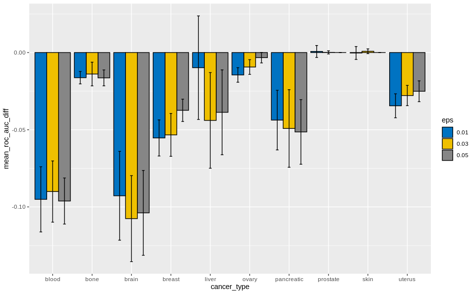

Можно видеть, что для prostate и skin тестовый ROC AUC отлчается незначительно в RP и RN, в то время как для остальных типов рака средний ROC AUC для RP ниже, чем для RN: до 5п. для bone, ovary, uterus и до 14% для blood, brain, breast, liver, pancreatic.

### Lift of precision and recall

Confidence interval for difference in median lift of recall (RP mode minus RN mode)

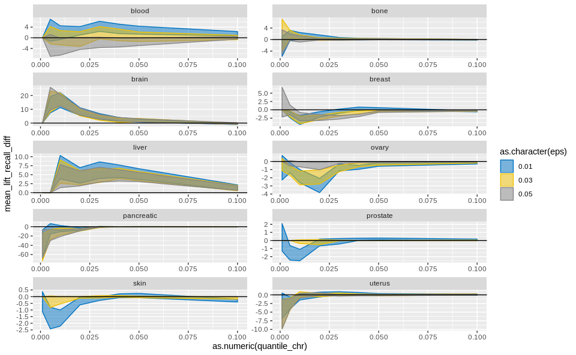

```r
ggplot(recall_ci_stats_bl %>%filter(quantile_chr != "0.15"),
       aes(x=as.numeric(quantile_chr), y=mean_lift_recall_diff, colour=as.character(eps))) +
  geom_ribbon(aes(ymin=ci_lower_lift_recall_diff, ymax=ci_upper_lift_recall_diff, fill=as.character(eps)), alpha=0.5) +
  facet_wrap(~ cancer_type, nrow = 5,scales = "free") +
  scale_fill_jco() +
  scale_color_jco() +
  geom_hline(yintercept = 0)
```

Выводы:

1. Для большинства типов рака разница в рассматриваемой метрике нестабильна (доверительный интервал включает 0), т.е. наблюдается случайный эффект.
2. Значимый (доверительный интервал находится выше 0 для всех probability quantile до 0,1) положительный эффект (прирост полноты больше в режиме RP) наблюдается для brain и liver
3. Значимый (доверительный интервал находится ниже 0 для всех probability quantile до 0,02) отрицательный эффект (прирост полноты меньше в режиме RP) наблюдается для pancreatic (eps=0.05), breast (eps=0.03), ovary (eps=0.01)

Стоит отметить, что устойчивый положительный эфффект наблюдается типов рака, входящих в топ-5 типов рака с минимальным количеством известных разрывов. При этом тип рака, для которого наблюдается максимальный положительный эффект от использования дополнтельных положительных примеров (brain), имеет минимальное количество разрывов (1561). Таким образом, в некоторых случаях использование дополнительно размеченных положительных примеров (окна, в которых пока не наблюдалось хотспотов, но по исследуемым характеристикам очень похожих на них) в условиях шумных данных (хотспоты размечены на очень маленьком количестве разрывов) помогает более качественно размечать тестовые примеры (хотспоты). Напротив, значимый отрицательный эффект наблюдается для типов рака, входящих в топ-4 типов рака с максимальным количеством известных разрывов. Таким образом, в некоторых случаях при наличии достаточного количества оснований для разметки хотспотов (т.е. разрывов), выделение дополнительных положительных примеров вносит шум.

Те же группы (и порядок типов рака в них) сохраняется и для median lift of precision.

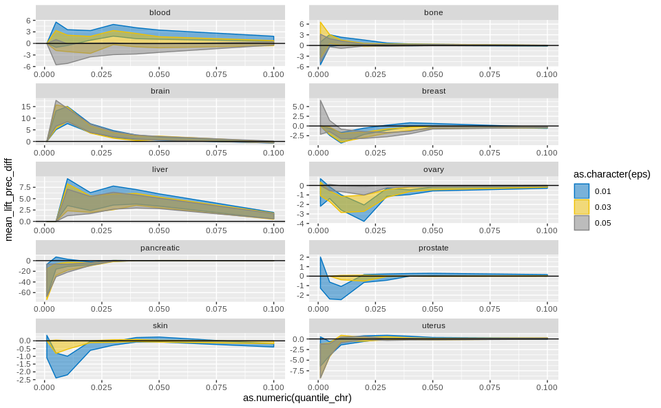

```r
ggplot(prec_ci_stats_bl %>%filter(quantile_chr != "0.15"),
       aes(x=as.numeric(quantile_chr), y=mean_lift_prec_diff, colour=as.character(eps))) +
  geom_ribbon(aes(ymin=ci_lower_lift_prec_diff, ymax=ci_upper_lift_prec_diff, fill=as.character(eps)), alpha=0.5) +
  facet_wrap(~ cancer_type, nrow = 5,scales = "free") +
  scale_fill_jco() +
  scale_color_jco() +
  geom_hline(yintercept = 0)
```

### Comparison with baseline

Lift of recall by type of PU learning for best epsilon

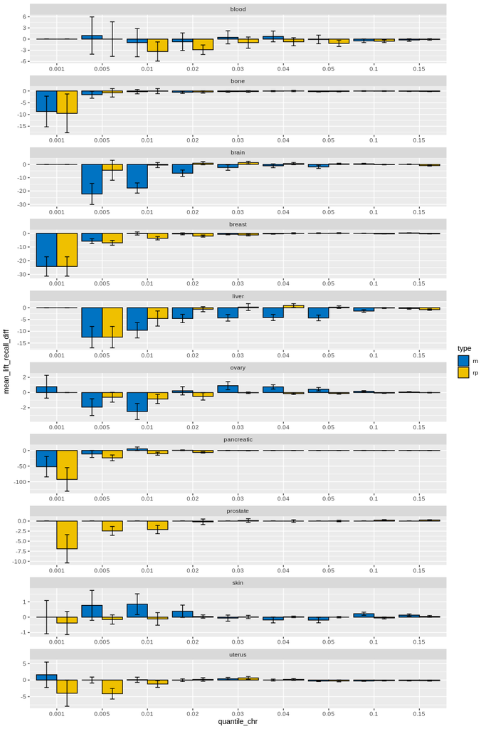

```r
ggplot(recall_ci_stats_bl_comp, aes(x=quantile_chr, y=mean_lift_recall_diff, fill=type)) +
  geom_bar(stat="identity", color="black", position=position_dodge()) +
  geom_errorbar(aes(ymin=ci_lower_lift_recall_diff, ymax=ci_upper_lift_recall_diff), width=.2, position=position_dodge(.9))+
  scale_fill_jco()+
  facet_wrap(~ cancer_type, nrow = 10, scales = "free")
```

Выводы: 1. Для большинcтва типов рака изменение процесса обучения модели с бинарной классификации на PU learning привело к снижению lift of recall. Это может объясняться тем, что так как при PU learning некоторые примеры могли не участвовать в обучении (если модель в них не была уверена), мы потеряли эти данные и впоследствии похожие на них примеры были оценены некорректно. 2. При RN mode для ovary и skin наблюдается “легкий” положительный эффект при определенных порогах (доверительный интервал выше 0). Для prostate наблюдается такое же качество, как при базовой модели. Если не рассматривать пороги мене 1%, то незначительные отклонения в +-1 имеют такие типы рака, как bone, breast, uterus 3. При RP mode для brain и uterus наблюдается “легкий” положительный эффект при определенных порогах (доверительный интервал выше 0).

Те же выводы применимы и к lift of precision.

Lift of precision all by type of PU learning for best epsilon

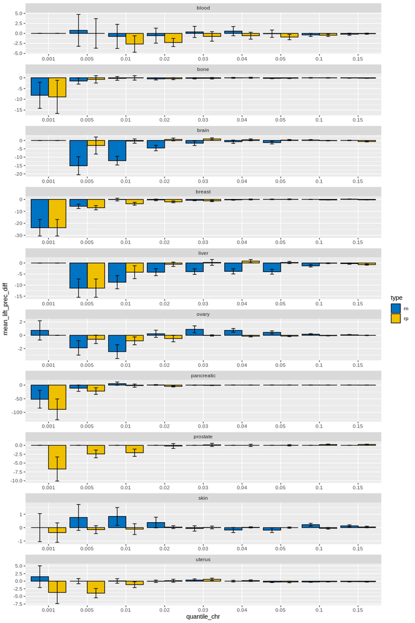

```r
ggplot(prec_ci_stats_bl_comp, aes(x=quantile_chr, y=mean_lift_prec_diff, fill=type)) +
  geom_bar(stat="identity", color="black", position=position_dodge()) +
  geom_errorbar(aes(ymin=ci_lower_lift_prec_diff, ymax=ci_upper_lift_prec_diff), width=.2, position=position_dodge(.9))+
  scale_fill_jco()+
  facet_wrap(~ cancer_type, nrow = 10, scales = "free")
```

ROC AUC

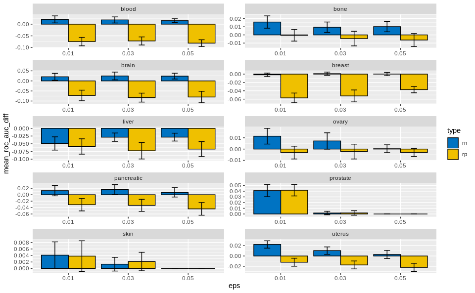

Можно заметить, что для большинства типов рака изменение ROC AUC в PU learning по сравнению с базовой моделью положительно для RN mode и отрицательно для RP mode (uterus, pancreatic, ovary, brain, bone, blood), в то время как положительный эффект в обоих случаях наблюдается для skin (незначительный) и prostate (для eps=0.01, одинаково большой прирост для RN и RP), а для liver - сильный отрицательный эффект. Для breast в процедуре RN нет изменений по сравнению с базовой моделью, а в процедуре RP - сильный отрицательный эффект.

```
Note: zip::zip() is deprecated, please use zip::zipr() instead
```

Выводы в целом: 1. PU learning не помог повысить качество классификации хотспотов (не выросли метрикиlift of recall/precision). Возможная причина - слишком сильная потеря данных в процессе обучения, ведущая к большей неопределенности. При этом для некоторых типов рака ROC AUC вырос на 1-5 п. в среднем, что говорит о том, что в целом положительные тестовые примеры стали ранжироваться выше, однако в топ примеров с максимальной вероятностью входит меньшее количество размеченных хотспотов (судя по данным recall).  
2. Если сравнивать два рассмотренных режима PU learning, то для brain cancer (тип рака с минимальным и в абсолютном значении очень маленьким количеством исходных данных о разрывах) RP режим позволяет поднабрать качество по сравнению с RN (за счет разметки новых примеров как положительных - т.е. учесть возможный шум в данных по причине их неполноты), в то время как для типов рака с достаточно большим количеством исходных данных о разрывах (breast, pancreatic) использование дополнительных положительных примеров вносит шум.